# Influência das Midias Sociais sobre discentes

## Introdução

Este trabalho é referente a uma pesquisa feita sobre o uso de redes sociais pelos discentes e docentes da universidade, e o que os mesmos acham sobre a utilização das redes sociais pelos professores/universidade com intuito educacional e dessa aproximação causada pelo uso.

Com base em um questionário aplicado na Universidade Estadual Paulista - UNESP no campus de Bauru, este trabalho visa responder a seguinte pergunta de pesquisa:

> *Quais são as influências das mídias sociais sobre discentes da instituição de nível superior unesp - Bauru - SP?*

## Perfil dos participantes

Essa pesquisa contou com 61 respostas validas para gerar seus resultados, o perfil dos participantes foi levantado através de perguntas sobre gênero, idade, estado civil e filhos.

Foi constatado que os participantes dessa pesquisa em sua totalidade são solteiros e não possuem filhos. Fato provavelmente justificado pela faixa etária dos participantes e pelo alvo da pesquisa ter sido uma universidade.

## Gênero dos Participantes

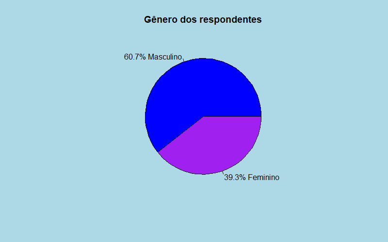

Gênero dos participantes

Segundo o gráfico abaixo, a maioria dos participantes tinha idade entre 21 e 25 anos, sendo 37 homens e 24 mulheres.

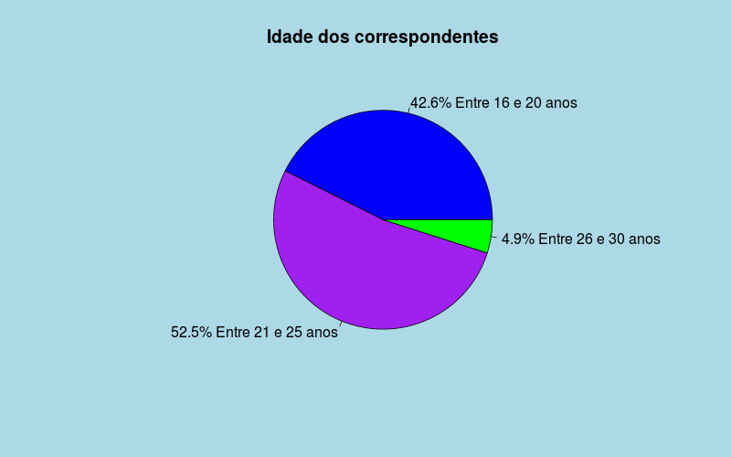

Idade dos participantes

## Redes Sociais

Rede social é uma plataforma cujo objetivo é conectar pessoas e compartilhar informações entre elas, tanto de caráter pessoal ou profissional, quanto educacional ou comercial. Elas se materializam na forma de sites e aplicativos, reunindo usuários que compactuam dos mesmos valores e interesses.

Com a rápida acensão das redes sociais, diversas dinâmicas do nosso cotidiano mudaram: buscas por emprego, amigos, compras, entre outros, estão cada vez mais compreendidas dentro das redes sociais.

E é nesse cenário que as redes de ensino se encontram e necessitam analisar quais são as vantagens, desavantagens e empecilhos para poderem, ou não, adentrarem de vez nessa nova era da tecnologia.

## Pesquisa

Esta pesquisa tentou entender tanto o perfil de uso das redes sociais pelos respondentes quanto seu posicionamento sobre a utilização de redes sociais no âmbito acadêmico.

Através de perguntaS sobre o tempo gasto em redes sociais e quais são as mais utilizadas, a pesquisa pode entender com qual afinco esse publico utiliza as redes no seu dia a dia.

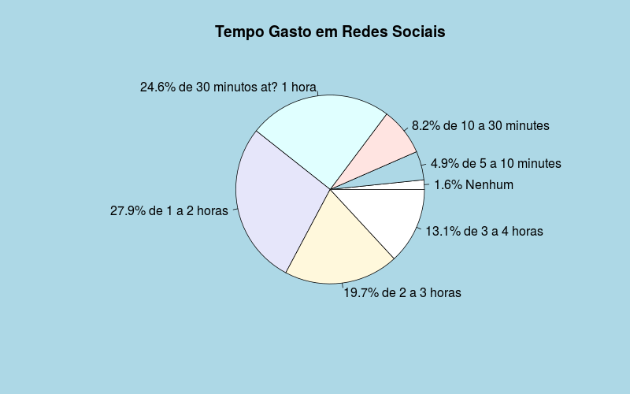

Gráfico tempo gasto em redes sociais

Os motivos de uso das redes também foi consultado, mostrando bastante sobre o perfil de uso dos respondentes.

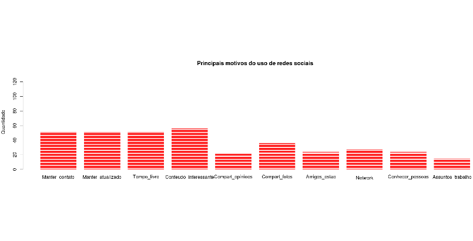

Principais motivos de uso

## Redes Sociais na Universidade

No campo institucional, criar planos para que a universidade participe destes meios pode potencializar ainda mais a ligação dos alunos e funcionários com a universidade.

Em sala de aula, as redes sociais permitem que estudantes e professores usem a criatividade, promovam debate, gerem conteúdos e aprendam. 62.3% dos que responderam a pesquisa, acham que sim, o professor deve utilizar as mídias sociais como uma forma de interação das aulas e 31.1% concordam mas com restrições.

Apesar de mais de 62% dos participantes acreditarem que as redes sociais devem ser utilizadas pelos professores, apenas 37,7% acreditam que essa é a melhor maneira de aproximação dos professores com os alunos. O gráfico a seguir ilustra isso.

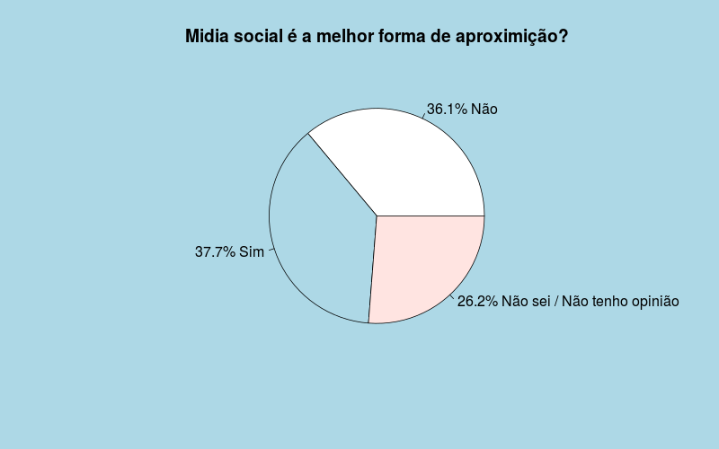

Mídia social é a melhor forma de aproximação?

Como são utilizadas diariamente, os usuários já estão acostumados e sabem muito bem utilizar essas plataformas, então utilizá-las essas redes sociais mais acessadas para aproximar os alunos do professor e da universidade pode ser bem efetiva mas ainda não deve ser o único meio de interação entre as partes.

Segundo os dados coletados na pesquisa, o Whatsapp é a plataforma mais utilizada, seguido pelo Youtube e Facebook.

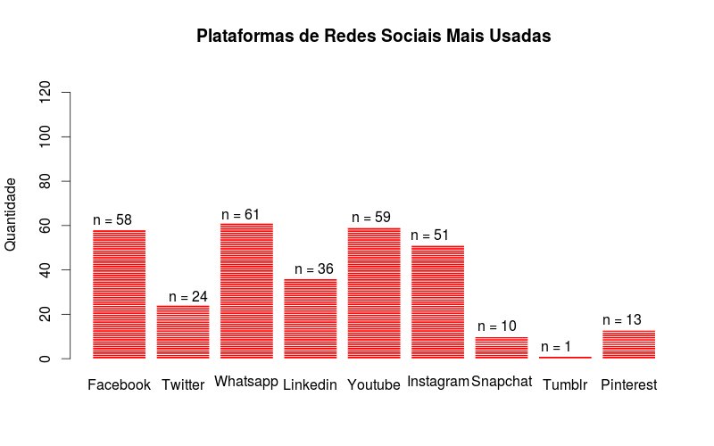

Plataformas mais usadas

Além disso, dentre os respondentes, 60.7% acreditam que os alunos alcançarão melhores resultados se as mídias sociais estiverem integradas às aulas e/ou atividades.

O que é um belo incentivo para se começar a utilizá-las em ambiente educacional.

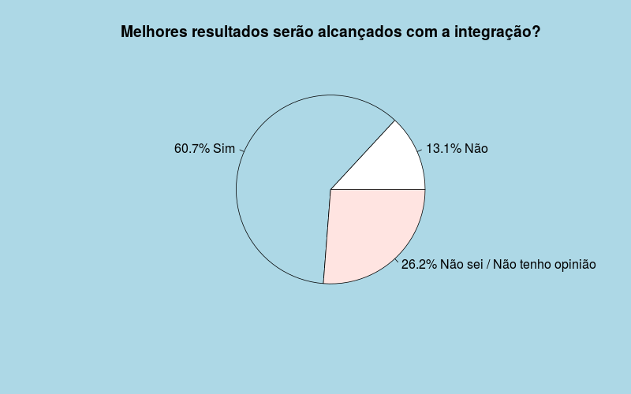

Gráfico melhores resultados

## Principais dificuldades do uso de redes sociais academicamente

Os participantes da pesquisa apontaram as principais dificuldades, segundo eles, que complicariam a utilização das redes sociais no âmbito acadêmico.

O problema mais destacado seria a grande possibilidade e facilidade de distração que as redes sociais oferecem sendo assim uma grande ferramenta contra produtiva e possivelmente o maior obstáculo para a utilização das redes sociais como meio de interação de alunos e professores.

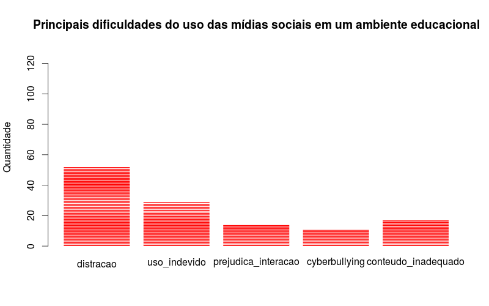

Dificuldades do uso de mídias sociais

## Recursos das redes sociais

No questionário os participantes encontraram uma tabela com alguns recursos oferecidos pelas redes sociais e foram instruídos para avaliarem o impacto desses recursos na educação.

Os recursos com melhor avaliação foram a possibilidade da troca de informações entre professores e alunos entre si.

[figure not shown]

Gráfico uso de grupos no Facebook

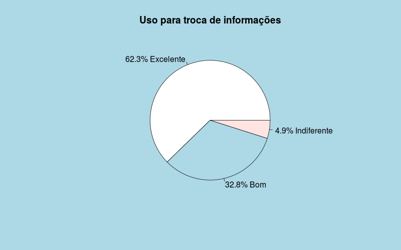

Gráfico uso de redes para troca de informações

## Conclusão

As redes sociais abrem um grande leque de possibilidades para os professores e para os alunos, facilitando a comunicação, disseminação e distribuição de conteúdo, graças a grande presença que as redes sociais tem nas vidas de grande parte da população. Mas apesar disso a utilização dessas mídias ainda pode trazer malefícios e deve ser analisada minunciosamente para que os objetivos sejam alcançados e os malefícios, como procrastinação e dispersão, sejam evitados ao máximo.

Como a grande maioria do mercado, o setor da educação tende cada vez mais ser integrado a essas redes seja elas como forma de apoio, divulgação ou integração entre professores e alunos. Logo as instituições devem pensar em alternativas e se prepararem para entrar nessa era.